# Data Wrangling Exercises - Instructions

365: Intro to Bayesian Analysis, Fall 2023

```r
library(tidyverse)
library(babynames)
library(gapminder)
library(readxl)
library(lubridate)
library(ggbeeswarm)
```

(Adapted from Steve Buyske, *Data Wrangling*)

## Intro

This segment is not specific to Bayesian analyses, but is instead about handling data in R. The functions are mostly from the `tidyverse` package. There are other ways to do the tasks that we are about to work through, but the tidyverse functions are particularly nice—they offer a consistent and easily read syntax.

We will be going through the material via a series of exercises. I **strongly** recommend trying each exercise before seeing what I have done. I’ve added lots of blank space to reduce the temptation to look ahead.

## Exercise 1

- Open the `Data Wrangling Exercises` project.
- Open a new R Notebook.
- Delete all of the text from “This is an …” on and save it with a name of your choice.
- Create a code chunk with a name of `setup` and load the `tidyverse`, `babynames`, `gapminder`, `readxl`, `lubridate`, and ``ggbeeswarm` packages. To load a package, type `library(tidyverse)`, for example, on a separate line.

You should have code that looks like lines 8–15 above.

## Datasets, data frames, and tibbles

“Dataset” is a generic term for, well, a set of data. “Data frame” refers to a type of object in R, which is basically a big rectangle of data with rows corresponding to observations and columns corresponding to variables. The columns can have different types of data (character, number, TRUE/FALSE, and so on). A tibble is a data frame with a few extra features, but basically it prints more nicely. There is one difference that sometimes matters, though: If you pull out a single column of a data frame, by default you will get a vector, and if you pull out a single element of a data frame, you will get a single string, number, TRUE or FALSE, and so on. If you do the same in a tibble, you will get another tibble.

If need be, you can convert a tibble to a data frame with `as.data.frame()` and a data frame to a tibble with `as_tibble()`.

```r
example_tbl <- tibble(x = 1:20, y = letters[1:20])
example_df <- as.data.frame(example_tbl)

example_tbl
```

| x | y |
| --- | --- |
| 1 | a |
| 2 | b |
| 3 | c |
| 4 | d |
| 5 | e |
| 6 | f |
| 7 | g |
| 8 | h |
| 9 | i |
| 10 | j |

[output cut: 10 more lines]

```r
example_tbl[, 1]
```

| x |
| --- |
| 1 |
| 2 |
| 3 |
| 4 |
| 5 |
| 6 |
| 7 |
| 8 |
| 9 |
| 10 |

[output cut: 10 more lines]

```r
example_df[, 1]
```

```
 [1]  1  2  3  4  5  6  7  8  9 10 11 12 13 14 15 16 17 18 19 20
```

```r
example_tbl[1, 2]
```

| y |
| --- |
| a |

```r
example_df[1, 2]
```

```
[1] "a"
```

## Babynames example

The `babynames` package has a data frame called `babynames`, which looks like

```r
babynames
```

| year | sex | name | n | prop |
| --- | --- | --- | --- | --- |
| 1880 | F | Mary | 7065 | 0.07238359 |
| 1880 | F | Anna | 2604 | 0.02667896 |
| 1880 | F | Emma | 2003 | 0.02052149 |
| 1880 | F | Elizabeth | 1939 | 0.01986579 |
| 1880 | F | Minnie | 1746 | 0.01788843 |
| 1880 | F | Margaret | 1578 | 0.01616720 |
| 1880 | F | Ida | 1472 | 0.01508119 |
| 1880 | F | Alice | 1414 | 0.01448696 |
| 1880 | F | Bertha | 1320 | 0.01352390 |
| 1880 | F | Sarah | 1288 | 0.01319605 |

[output cut: 990 more lines]

Here’s the code to restrict to the name `Quinn`, restrict to 1980 and later, and to plot with separate colors for girls and boys.

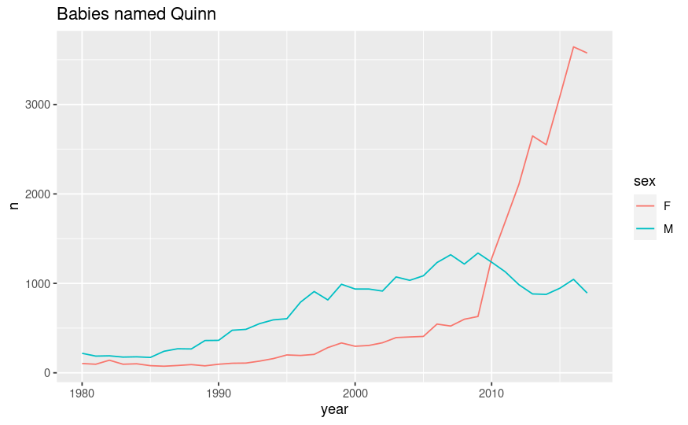

```r
babynames %>%
  filter(name == "Quinn", year >= 1980) %>%
  ggplot(aes(x = year, y = n, colour = sex)) +
     geom_line() +
     ggtitle("Babies named Quinn")
```

## Exercise 2

- Try making a similar plot of “Taylor”.
- Add points to your plot by adding the code `+ geom_point()`

```r
babynames %>%
  filter(name == "Taylor", year >= 1980) %>%
  ggplot(aes(x = year, y = n, colour = sex)) +
     geom_line() + geom_point() +
     ggtitle("Babies named Taylor")
```

You should have something like

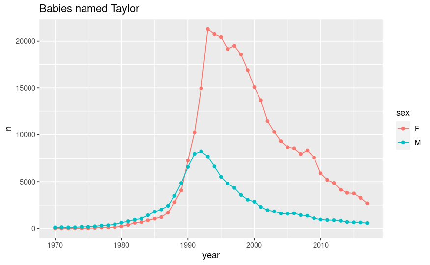

```r
babynames %>%
  filter(name == "Taylor", year >= 1970) %>%
  ggplot(aes(x = year, y = n, colour = sex)) +
     geom_line() +
     geom_point() +
     ggtitle("Babies named Taylor")
```

## `group_by()` and `summarize()`

- We often want to summarize some aspect of a data frame by a grouping variable, or variables.
  - For example, how often were different baby names given this century?
- The two functions `group_by()` and `summarize()` will help you do so.
- E.g.,

```r
babynames %>% filter(year >= 2000) %>%
  group_by(name) %>%
  summarize(total = sum(n))
```

| name | total |
| --- | --- |
| Aaban | 107 |
| Aabha | 35 |
| Aabid | 10 |
| Aabir | 5 |
| Aabriella | 32 |
| Aada | 5 |
| Aadam | 202 |
| Aadan | 130 |
| Aadarsh | 199 |
| Aaden | 4658 |

[output cut: 990 more lines]

- Notice the addition of `arrange()` at the end, to sort the data, combined with `desc()` which puts a variable in descending order.

```r
babynames %>%
  filter(year >= 2000) %>%
  group_by(name) %>%
  summarize(total = sum(n)) %>%
  arrange(desc(total))
```

| name | total |
| --- | --- |
| Jacob | 414575 |
| Michael | 373882 |
| Emma | 340240 |
| Ethan | 327828 |
| Matthew | 327440 |
| William | 326035 |
| Emily | 324576 |
| Joshua | 324254 |
| Daniel | 316034 |
| Olivia | 303856 |

[output cut: 990 more lines]

- Notice the new explicit use of `head()`, with n = 5 to show the first 5 entries.

```r
babynames %>% filter(year >= 2000) %>%
  group_by(name) %>%
  summarize(total = sum(n)) %>%
  arrange(desc(total)) %>%
  head(n = 5)
```

| name | total |
| --- | --- |
| Jacob | 414575 |
| Michael | 373882 |
| Emma | 340240 |
| Ethan | 327828 |
| Matthew | 327440 |

## Exercise 3

What were the five most common baby names between 1901 and 1920?

| name | total |
| --- | --- |
| Mary | 696597 |
| John | 510509 |
| William | 415530 |
| James | 379800 |
| Helen | 347193 |

You should have something like

```r
babynames %>% filter(year >= 1901, year <= 1920) %>%
  group_by(name) %>%
  summarize(total = sum(n)) %>%
  arrange(desc(total)) %>%
  head(n = 5)
```

| name | total |
| --- | --- |
| Mary | 696597 |
| John | 510509 |
| William | 415530 |
| James | 379800 |
| Helen | 347193 |

## select()

- You can use `select()` to select only some of the variables in the data frame

```r
babynames %>%
  select(name, year, sex, n) %>%
  head(n = 3)
```

| name | year | sex | n |
| --- | --- | --- | --- |
| Mary | 1880 | F | 7065 |
| Anna | 1880 | F | 2604 |
| Emma | 1880 | F | 2003 |

- You can also use `select()` to “unselect” by using a negative sign:

```r
babynames %>%
  select(-prop) %>%
  head(n = 3)
```

| year | sex | name | n |
| --- | --- | --- | --- |
| 1880 | F | Mary | 7065 |
| 1880 | F | Anna | 2604 |
| 1880 | F | Emma | 2003 |

## Adding derived variables with `mutate()`

Often I want to create a new variable in a data frame by doing some calculation on the existing variables. The function to do so is `mutate()`.

For example, suppose I want to add a variable for the gdp in the `gapminder` data frame by multiplying `pop` and `gdpPercap`

```r
gapminder_with_gdp <-
  gapminder %>%
  mutate(gdp = pop * gdpPercap)

gapminder_with_gdp
```

| country | continent | year | lifeExp | pop | gdpPercap | gdp |
| --- | --- | --- | --- | --- | --- | --- |
| Afghanistan | Asia | 1952 | 28.80100 | 8425333 | 779.4453 | 6.567086e+09 |
| Afghanistan | Asia | 1957 | 30.33200 | 9240934 | 820.8530 | 7.585449e+09 |
| Afghanistan | Asia | 1962 | 31.99700 | 10267083 | 853.1007 | 8.758856e+09 |
| Afghanistan | Asia | 1967 | 34.02000 | 11537966 | 836.1971 | 9.648014e+09 |
| Afghanistan | Asia | 1972 | 36.08800 | 13079460 | 739.9811 | 9.678553e+09 |
| Afghanistan | Asia | 1977 | 38.43800 | 14880372 | 786.1134 | 1.169766e+10 |
| Afghanistan | Asia | 1982 | 39.85400 | 12881816 | 978.0114 | 1.259856e+10 |
| Afghanistan | Asia | 1987 | 40.82200 | 13867957 | 852.3959 | 1.182099e+10 |
| Afghanistan | Asia | 1992 | 41.67400 | 16317921 | 649.3414 | 1.059590e+10 |
| Afghanistan | Asia | 1997 | 41.76300 | 22227415 | 635.3414 | 1.412200e+10 |

[output cut: 990 more lines]

## Exercise 4

- Create a new data frame `gapminder_extended` by adding a new variable that is the log base 10 of `gdpPercap`.
- `log10()` calculates the log base 10; `log()` is the natural log.

[output not shown]

[output cut: 990 more lines]

You should have something like

```r
gapminder_extended <-
  gapminder %>%
  mutate(lgdpPercap = log10(gdpPercap))

head(gapminder_extended, n = 3)
```

| country | continent | year | lifeExp | pop | gdpPercap | lgdpPercap |
| --- | --- | --- | --- | --- | --- | --- |
| Afghanistan | Asia | 1952 | 28.801 | 8425333 | 779.4453 | 2.891786 |
| Afghanistan | Asia | 1957 | 30.332 | 9240934 | 820.8530 | 2.914265 |
| Afghanistan | Asia | 1962 | 31.997 | 10267083 | 853.1007 | 2.931000 |

By the way, you can define as many new variables as you want; just separate them by commas inside `mutate()`.

## `pivot_wider()` and `pivot_longer()`

- Sometimes we want the data to be “wide” and sometimes we want it to be “tall” or “long”.
- E.g., the `babynames` data frame is long, with many rows and few columns:

```r
babynames %>%
  filter(year >= 2000) %>%
  select(-prop) %>%
  head(n = 3)
```

| year | sex | name | n |
| --- | --- | --- | --- |
| 2000 | F | Emily | 25953 |
| 2000 | F | Hannah | 23080 |
| 2000 | F | Madison | 19967 |

The long format is almost always what you want for plotting and for other analyses, but people often prefer to look at wide data. You can use the `pivot_wider()` function to go from long to wide. The animation https://www.dropbox.com/s/a6o75zj443b2rv3/tidyr-longer-wider-modified.gif?dl=0 from [Mara Averick](https://twitter.com/dataandme/status/1175913657907253254) illustrates what `pivot_wider()` and its companion, `pivot_longer()`, do.

```r
babynames_wide <- babynames %>%
  filter(year >= 2000) %>%
  select(-prop) %>%
  pivot_wider(names_from = "year", values_from = "n")

babynames %>%
  head(n = 3)
```

| year | sex | name | n | prop |
| --- | --- | --- | --- | --- |
| 1880 | F | Mary | 7065 | 0.07238359 |
| 1880 | F | Anna | 2604 | 0.02667896 |
| 1880 | F | Emma | 2003 | 0.02052149 |

```r
babynames_wide %>%
  head(n = 3)
```

| sex | name | 2000 | 2001 | 2002 | 2003 | 2004 | 2005 | 2006 | 2007 | 2008 | 2009 | 2010 | 2011 | 2012 | 2013 | 2014 | 2015 | 2016 | 2017 |
| --- | --- | --- | --- | --- | --- | --- | --- | --- | --- | --- | --- | --- | --- | --- | --- | --- | --- | --- | --- |
| F | Emily | 25953 | 25055 | 24463 | 25688 | 25033 | 23937 | 21400 | 19355 | 17429 | 15345 | 14268 | 14251 | 13646 | 13124 | 12642 | 11780 | 10957 | 9746 |
| F | Hannah | 23080 | 20712 | 18819 | 17634 | 15604 | 14845 | 14544 | 13304 | 9560 | 7568 | 6987 | 6566 | 7274 | 7294 | 6579 | 6406 | 6002 | 5872 |
| F | Madison | 19967 | 22164 | 21773 | 20197 | 20622 | 19566 | 18625 | 17958 | 17027 | 15235 | 13176 | 12381 | 11392 | 10591 | 10315 | 10087 | 9014 | 7847 |

- You can go from tall to wide with `pivot_wider()`
- the `names_from` argument will give new column names
- the `values_from` argument will give the values in those columns
- all other variables determine the unique rows
  - you may need to dump variables using select

## Exercise 5

- Take the `gapminder` data frame and keep only the `country`, `year`, and `lifeExp` variables
- Turn the resulting data frame into a wide data frame
- Assign the result to an object name of your choice
- Show the first 3 rows

[output not shown]

```r
gapminder_wide <- gapminder %>%
  select(country, year, lifeExp) %>%
  pivot_wider(names_from = "year", values_from = "lifeExp")

gapminder %>%
  head(n = 3)


gapminder_wide %>%
  head(n = 3)
```

| country | 1952 | 1957 | 1962 | 1967 | 1972 | 1977 | 1982 | 1987 | 1992 | 1997 | 2002 | 2007 |
| --- | --- | --- | --- | --- | --- | --- | --- | --- | --- | --- | --- | --- |
| Afghanistan | 28.801 | 30.332 | 31.997 | 34.020 | 36.088 | 38.438 | 39.854 | 40.822 | 41.674 | 41.763 | 42.129 | 43.828 |
| Albania | 55.230 | 59.280 | 64.820 | 66.220 | 67.690 | 68.930 | 70.420 | 72.000 | 71.581 | 72.950 | 75.651 | 76.423 |
| Algeria | 43.077 | 45.685 | 48.303 | 51.407 | 54.518 | 58.014 | 61.368 | 65.799 | 67.744 | 69.152 | 70.994 | 72.301 |

You should have something like

```r
gapminder_wide <- gapminder %>%
  select(country, year, lifeExp) %>%
  pivot_wider(names_from = "year", values_from = "lifeExp")

gapminder_wide %>%
  head(n = 3)
```

| country | 1952 | 1957 | 1962 | 1967 | 1972 | 1977 | 1982 | 1987 | 1992 | 1997 | 2002 | 2007 |
| --- | --- | --- | --- | --- | --- | --- | --- | --- | --- | --- | --- | --- |
| Afghanistan | 28.801 | 30.332 | 31.997 | 34.020 | 36.088 | 38.438 | 39.854 | 40.822 | 41.674 | 41.763 | 42.129 | 43.828 |
| Albania | 55.230 | 59.280 | 64.820 | 66.220 | 67.690 | 68.930 | 70.420 | 72.000 | 71.581 | 72.950 | 75.651 | 76.423 |
| Algeria | 43.077 | 45.685 | 48.303 | 51.407 | 54.518 | 58.014 | 61.368 | 65.799 | 67.744 | 69.152 | 70.994 | 72.301 |

- Go from wide to long with `pivot_longer()`
- the `cols` argument speicifies the columns to convert to long format (try `?select_helpers` for some of the ways to specify the columns)
- the `names_to` argument gives the variable name for the variable created from the columns
- the `values_to` argument gives the variable name for the variable of the values from those columns

```r
babynames_wide %>%
  head(n = 3)
```

| sex | name | 2000 | 2001 | 2002 | 2003 | 2004 | 2005 | 2006 | 2007 | 2008 | 2009 | 2010 | 2011 | 2012 | 2013 | 2014 | 2015 | 2016 | 2017 |
| --- | --- | --- | --- | --- | --- | --- | --- | --- | --- | --- | --- | --- | --- | --- | --- | --- | --- | --- | --- |
| F | Emily | 25953 | 25055 | 24463 | 25688 | 25033 | 23937 | 21400 | 19355 | 17429 | 15345 | 14268 | 14251 | 13646 | 13124 | 12642 | 11780 | 10957 | 9746 |
| F | Hannah | 23080 | 20712 | 18819 | 17634 | 15604 | 14845 | 14544 | 13304 | 9560 | 7568 | 6987 | 6566 | 7274 | 7294 | 6579 | 6406 | 6002 | 5872 |
| F | Madison | 19967 | 22164 | 21773 | 20197 | 20622 | 19566 | 18625 | 17958 | 17027 | 15235 | 13176 | 12381 | 11392 | 10591 | 10315 | 10087 | 9014 | 7847 |

```r
babynames_wide %>%
  pivot_longer(
    cols = `2000`:`2017`,
    names_to = "year",
    values_to = "count")
```

| sex | name | year | count |
| --- | --- | --- | --- |
| F | Emily | 2000 | 25953 |
| F | Emily | 2001 | 25055 |
| F | Emily | 2002 | 24463 |
| F | Emily | 2003 | 25688 |
| F | Emily | 2004 | 25033 |
| F | Emily | 2005 | 23937 |
| F | Emily | 2006 | 21400 |
| F | Emily | 2007 | 19355 |
| F | Emily | 2008 | 17429 |
| F | Emily | 2009 | 15345 |

[output cut: 990 more lines]

## Exercise 6

- Change the wide version of gapminder that you saved and convert it to a long version.

| country | year | count |
| --- | --- | --- |
| Afghanistan | 1952 | 28.80100 |
| Afghanistan | 1957 | 30.33200 |
| Afghanistan | 1962 | 31.99700 |
| Afghanistan | 1967 | 34.02000 |
| Afghanistan | 1972 | 36.08800 |
| Afghanistan | 1977 | 38.43800 |
| Afghanistan | 1982 | 39.85400 |
| Afghanistan | 1987 | 40.82200 |
| Afghanistan | 1992 | 41.67400 |
| Afghanistan | 1997 | 41.76300 |

[output cut: 990 more lines]

You should have something like

```r
gapminder_wide %>%
  pivot_longer(-country,  names_to = "year", values_to = "life_expectancy")
```

| country | year | life_expectancy |
| --- | --- | --- |
| Afghanistan | 1952 | 28.80100 |
| Afghanistan | 1957 | 30.33200 |
| Afghanistan | 1962 | 31.99700 |
| Afghanistan | 1967 | 34.02000 |
| Afghanistan | 1972 | 36.08800 |
| Afghanistan | 1977 | 38.43800 |
| Afghanistan | 1982 | 39.85400 |
| Afghanistan | 1987 | 40.82200 |
| Afghanistan | 1992 | 41.67400 |
| Afghanistan | 1997 | 41.76300 |

[output cut: 990 more lines]

The vignette at https://tidyr.tidyverse.org/articles/pivot.html does a very nice job of showing simple examples of pivoting followed by more extended examples showing the use of most of the optional arguments

## Reading Excel files with `read_excel()`

```r
penguins <- read_excel("penguins.xlsx")

penguins
```

| species | island | bill_length_mm | bill_depth_mm | flipper_length_mm | body_mass_g | sex | year |
| --- | --- | --- | --- | --- | --- | --- | --- |
| Adelie | Torgersen | 39.1 | 18.7 | 181 | 3750 | male | 2007 |
| Adelie | Torgersen | 39.5 | 17.4 | 186 | 3800 | female | 2007 |
| Adelie | Torgersen | 40.3 | 18.0 | 195 | 3250 | female | 2007 |
| Adelie | Torgersen | NA | NA | NA | NA | NA | 2007 |
| Adelie | Torgersen | 36.7 | 19.3 | 193 | 3450 | female | 2007 |
| Adelie | Torgersen | 39.3 | 20.6 | 190 | 3650 | male | 2007 |
| Adelie | Torgersen | 38.9 | 17.8 | 181 | 3625 | female | 2007 |
| Adelie | Torgersen | 39.2 | 19.6 | 195 | 4675 | male | 2007 |
| Adelie | Torgersen | 34.1 | 18.1 | 193 | 3475 | NA | 2007 |
| Adelie | Torgersen | 42.0 | 20.2 | 190 | 4250 | NA | 2007 |

[output cut: 334 more lines]

The data itself comes from the `palmerpenguins` package (intended as an alternative to the widely used iris dataset).

The defaults for `read_excel()` are to read from the first sheet, to assume that there are column headers, and to read all of the sheet. Here’s an example with changes from the defaults.

```r
penguin_latin <- read_excel("penguins.xlsx", sheet = 2, skip = 3, n_max = 3)

penguin_latin
```

| Common name | Latin name |
| --- | --- |
| Adelie | Pygoscelis adeliae |
| Gentoo | Pygoscelis papua |
| Chinstrap | Pygoscelis antarcticus |

## Merging data frames using `full_join()`

We often want to merge different data frame. Here’s an example

```r
full_join(penguins, penguin_latin, by = c("species" = "Common name"))
```

| species | island | bill_length_mm | bill_depth_mm | flipper_length_mm | body_mass_g | sex | year | Latin name |
| --- | --- | --- | --- | --- | --- | --- | --- | --- |
| Adelie | Torgersen | 39.1 | 18.7 | 181 | 3750 | male | 2007 | Pygoscelis adeliae |
| Adelie | Torgersen | 39.5 | 17.4 | 186 | 3800 | female | 2007 | Pygoscelis adeliae |
| Adelie | Torgersen | 40.3 | 18.0 | 195 | 3250 | female | 2007 | Pygoscelis adeliae |
| Adelie | Torgersen | NA | NA | NA | NA | NA | 2007 | Pygoscelis adeliae |
| Adelie | Torgersen | 36.7 | 19.3 | 193 | 3450 | female | 2007 | Pygoscelis adeliae |
| Adelie | Torgersen | 39.3 | 20.6 | 190 | 3650 | male | 2007 | Pygoscelis adeliae |
| Adelie | Torgersen | 38.9 | 17.8 | 181 | 3625 | female | 2007 | Pygoscelis adeliae |
| Adelie | Torgersen | 39.2 | 19.6 | 195 | 4675 | male | 2007 | Pygoscelis adeliae |
| Adelie | Torgersen | 34.1 | 18.1 | 193 | 3475 | NA | 2007 | Pygoscelis adeliae |
| Adelie | Torgersen | 42.0 | 20.2 | 190 | 4250 | NA | 2007 | Pygoscelis adeliae |

[output cut: 334 more lines]

There are is also a `left_join()` function, which includes only observations in the first data frame; a `right_join()` function that is includes only observations in the second data frame; and `inner_join()` that includes only observations that are in both datasets. The most commonly used join is `left_join()`, which you use this whenever you are adding data from another dataset. You can find more details at https://rafalab.github.io/dsbook/joining-tables.html

## Exercise 7

- Merge the data frames `band_members` and `band_instruments2`.

[output not shown]

You should have something like

[output not shown]

```r
full_join(band_members, band_instruments2, by = c("name" = "artist"))
```

## Dates with the `lubridate` package

This is a small thing, but dates can be really annoying. This vector consists of strings all referring to the same date.

```r
halloween <- c("10/31/20", "10/31/2020", "Oct 31, 2020", "October 31, 2020")
```

You can convert those to a common format

```r
mdy(halloween)
```

```
[1] "2020-10-31" "2020-10-31" "2020-10-31" "2020-10-31"
```

All you need to do is specify the order of the month, day, and year; there are functions `dmy()`, `ymd()`, and so on.

## Other geoms

We will close out with a very quick look at some other ways of looking at data using the `ggplot()` function. You can find many others by searching Help for functions starting with `geom_` or doing web searches of ggplot2 and whatever kind of figure you are looking for.

### Boxplots

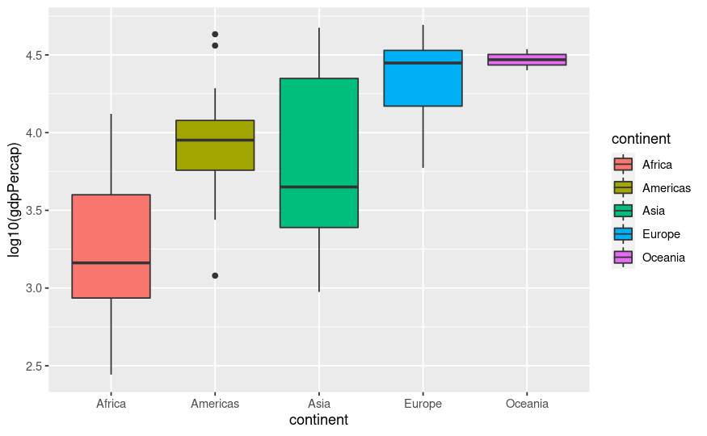

```r
gapminder %>%
  filter(year == 2007) %>%
  ggplot(aes(x = continent, y = log10(gdpPercap), fill = continent)) +
  geom_boxplot()
```

### Density

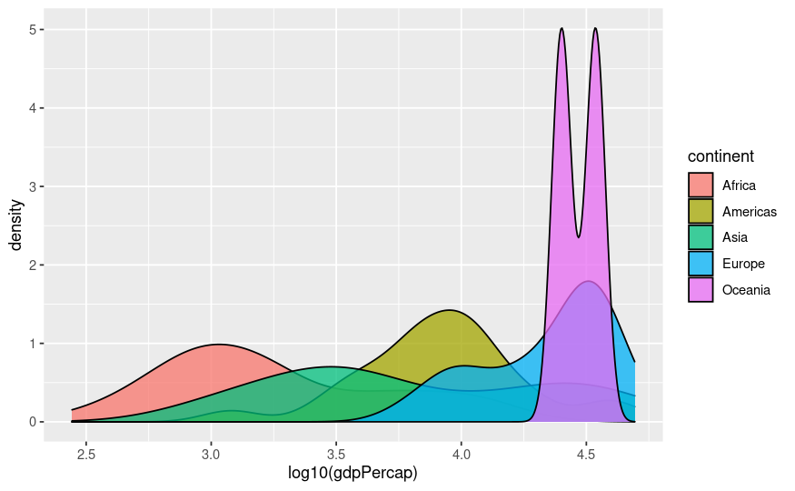

```r
gapminder %>%
  filter(year == 2007) %>%
  ggplot(aes(x  = log10(gdpPercap), fill = continent)) +
  geom_density(alpha = 0.75)
```

### Violin

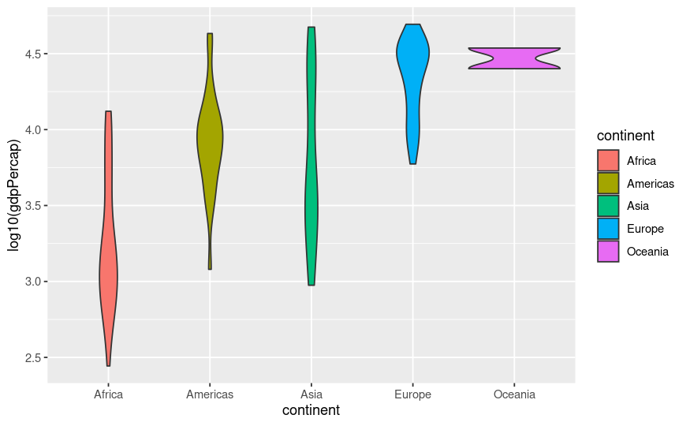

```r
gapminder %>%
  filter(year == 2007) %>%
  ggplot(aes(x = continent, y = log10(gdpPercap), fill = continent)) +
  geom_violin()
```

### Beeswarm

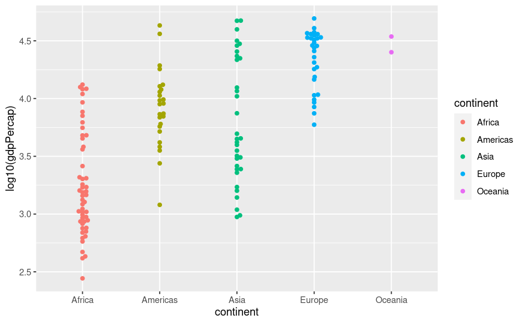

```r
gapminder %>%
  filter(year == 2007) %>%
  ggplot(aes(x = continent, y = log10(gdpPercap), colour = continent)) +
  geom_beeswarm()
```

### Beeswarm and boxplot

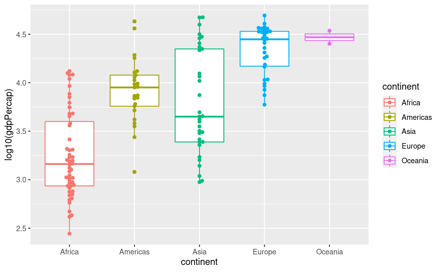

```r
gapminder %>%
  filter(year == 2007) %>%
  ggplot(aes(x = continent, y = log10(gdpPercap), colour = continent)) +
  geom_boxplot() +
  geom_beeswarm()
```

### Beeswarm and violin

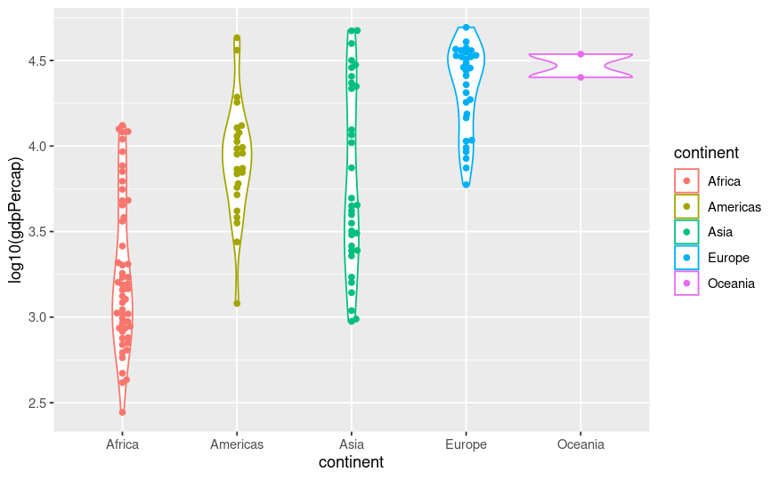

```r
gapminder %>%
  filter(year == 2007) %>%
  ggplot(aes(x = continent, y = log10(gdpPercap), colour = continent)) +
  geom_violin() +
  geom_beeswarm()
```

### Points and 2d density

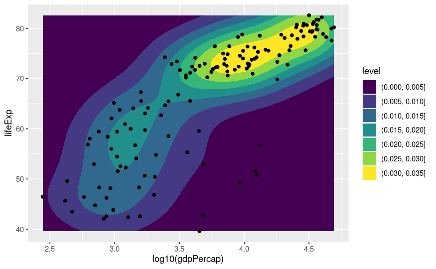

```r
gapminder %>%
  filter(year == 2007) %>%
  ggplot(aes(x = log10(gdpPercap), y = lifeExp)) +
  geom_density2d_filled() +
  geom_point()
```